# The Weather Lately

## What has the weather been doing?

For my observational study, I tracked the weather at quasi-random times throughout the day - generally whenever I stepped outside.

These observations were logged through a Google Form, which included the following questions:

- What is the current weather condition?
- What is the current wind strength?
- What is the current temperature in degree Celsius (°C)?
- What is the approximate colour of the sky?
- Do you notice any interesting or unusual atmospheric phenomena?
  - If yes - what do you notice?

## The Observations

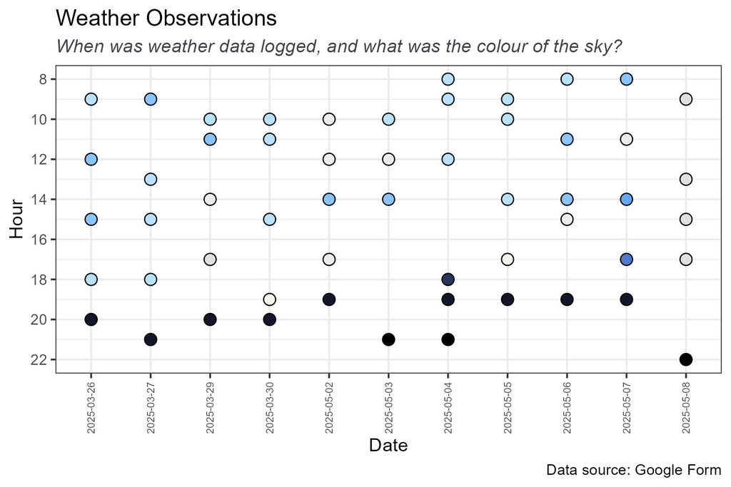

Scatterplot showing the hour observations were logged each day. The data points are coloured according to the sky colour at the time of observation

Overall, there were 55 weather instances logged over 11 days. Most days, I checked the weather around 4-6 times, from between 8AM to 10PM.

The data is recorded in two ‘parts’. There is a block recorded in late March, and another recorded in early May. April is skipped. During this period, Daylight Savings occurred, and we can see this change reflected in the way the sky starts to get darker earlier in the latter entries.

The colour of the sky comes from a reference key included the Google Form:

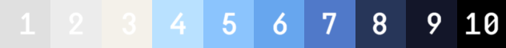

Scale of ten colours labelled 1-10, ranging from grey, to yellow, to blue, to black

## Rain, Hail, or Shine

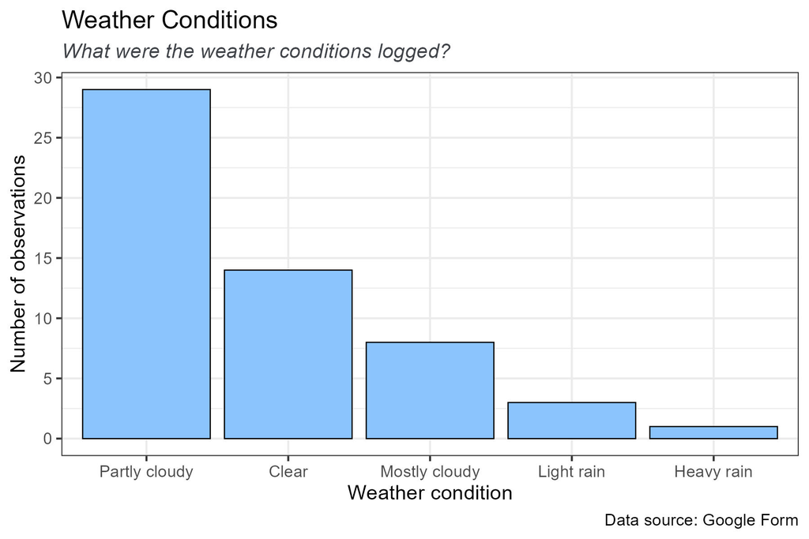

Vertical bar graph showing the counts for observed weather conditions

For the instances I logged data, the weather was generally partly cloudy, clear, or overcast. There was very minimal rain.

Anecdotally, it was an unusually fine spell when I started recording the data, I wasn’t recording for the several weeks we had torrential rain during April, and then it was mostly fine again.

## Changing of the Seasons

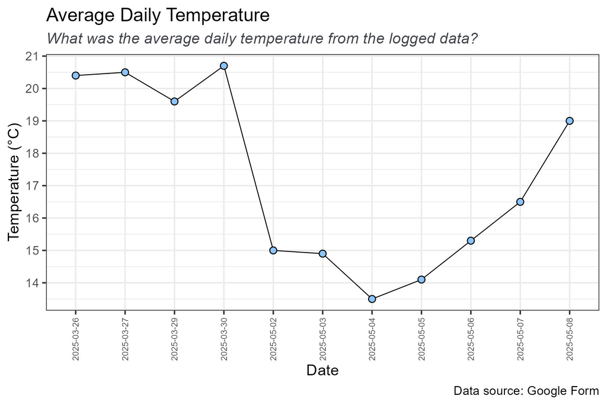

Lineplot with points at the data values, showing the daily average temperature

Since the data was logged throughout the day, it can be used to get a general average of the daytime temperature.

As mentioned above, we are missing weather information from April. However, from this graph, we can see a drop in the average temperature from March to May. This reflects the transition from the start of Autumn, to the end.

## Conclusion

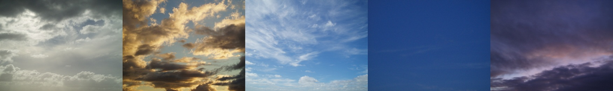

Horizontal collage of five sky images

From my collected data, we can see on a small scale what the weather has been like in Tāmaki Makaurau over an 11 day period, and the slow ways it’s changed as we move through Autumn.